# Séance 2 : Régression Linéaire - APPLICATION

On va étudier ici la validité de la courbe de Phillips pour la France. La courbe de Phillipps illustre la **relation inverse entre taux de chômage et taux d’inflation** démontrée empiriquement par l’économiste néo-zélandais **William Phillips** en 1958 sur le Royaume-Uni. Le concept a ensuite été repris par **Samuelson** et **Solow** dans le développement des modèles néo-keynésiens.

Afin de justifier cette relation sur le plan **théorique**, l’explication la plus populaire se fonde sur les **pouvoirs de négociation des salariés**. **Lorsque le taux de chômage est haut, les salariés sont “facilement” remplaçables dans les entreprises**. Ils ne peuvent donc pas négocier de **hausse de salaires** car les entreprises les remplaçeraient par d’autres au chômage. **Si les salaires n’augmentent pas**, les prix pratiqués par les entreprises n’ont pas de raison d’augmenter (parce que les coûts n’augmentent pas d’une part, et parce que la demande n’augmente pas d’autre part), donc **l’inflation n’augmente pas**. A contrario, lorsque le taux de chômage est faible, les salariés ont un pouvoir de négociation important. Ils vont donc demander des hausses de salaire, ce qui va se répercuter sur les prix.

Il y aurait donc un arbitrage à effectuer. En effet, les Banques Centrales ont pour mission de stabiliser l’inflation à un niveau faible. **La validité de la courbe de Phillips implique donc que cette inflation faible entraîne mécaniquement un chômage structurel permanent et l’impossibilité du Plein-Emploi**. Mais dans le même temps, les Etats (et les pouvoirs élus) ont un intérêt d’atteindre le Plein-Emploi (pour être réélus), donc à mener des politiques monétaire accomodantes qui entraînent une hausse de l’inflation sur le long-terme. C’est le problème de l’incohérence temporelle théorisée par Kydland & Prescott (1977), et les sociétés doivent donc choisir, entre l’inflation et le chômage.

Suivant la courbe de Phillips, le taux d’inflation $\pi$ à la période $t$, noté $\pi_t$, est une fonction du taux de chômage $U$ à la même période. Formellement:

$$\pi_t = \alpha + \beta U_t +
\varepsilon_t$$

On peut tester cette relation pour le cas de la France, en selectionnant uniquement la France dans la base de données data_schularick

```r
#installer les packages qu'on va utiliser si besoin (besoin de l'installer 1 seule fois sur un ordinateur, ensuite la fonction require() suffit.)

#install.packages("fixest")
#install.packages("tidyverse")
#install.packages("readxl")
#install.packages("zoo")
```

```r
require(tidyverse)
require(fixest)
require(readxl)

donnees <- read_excel("C:/users/fkraus/Desktop/data_schularick.xlsx") %>%
  filter(country == "France")

head(donnees)
```

| year | country | iso | ifs | pop | rgdpmad | rgdpbarro | rconsbarro | gdp | iy | cpi | ca | imports | exports | narrowm | money | stir | ltrate | hpnom | unemp | wage | debtgdp | revenue | expenditure | xrusd | tloans | tmort | thh | tbus | bdebt | … |
| --- | --- | --- | --- | --- | --- | --- | --- | --- | --- | --- | --- | --- | --- | --- | --- | --- | --- | --- | --- | --- | --- | --- | --- | --- | --- | --- | --- | --- | --- | --- |
| 1870 | France | FRA | 132 | 38440 | 1875.651 | 9.581409 | 14.11 | 0.23959 | 0.1018538 | 0.06186037 | 0.01101 | 0.02867 | 0.02802 | 0.097 | 0.103 | 6.00 | 5.792 | 0.02045860 | NA | 0.01458031 | NA | 0.0166 | 0.0317 | 0.04510263 | NA | 0.0087 | NA | NA | NA | … |
| 1871 | France | FRA | 132 | 37731 | 1899.407 | 10.021148 | 13.04 | 0.23682 | 0.0915230 | 0.06457950 | 0.00555 | 0.03567 | 0.02873 | 0.104 | 0.109 | 5.50 | 5.401 | 0.01876437 | NA | 0.01480813 | NA | 0.0201 | 0.0305 | 0.04677646 | NA | 0.0088 | NA | NA | NA | … |
| 1872 | France | FRA | 132 | 37679 | 2078.427 | 10.549079 | 14.36 | 0.24955 | 0.1208533 | 0.06389972 | 0.01503 | 0.03570 | 0.03762 | 0.107 | 0.112 | 5.00 | 5.592 | 0.01828487 | NA | 0.01520163 | NA | 0.0250 | 0.0272 | 0.04683248 | NA | 0.0089 | NA | NA | NA | … |
| 1873 | France | FRA | 132 | 37887 | 1922.096 | 10.401316 | 13.87 | 0.24220 | 0.1118793 | 0.06389972 | 0.01547 | 0.03555 | 0.03787 | 0.112 | 0.117 | 4.75 | 5.128 | 0.01767751 | NA | 0.01553300 | NA | 0.0268 | 0.0287 | 0.04582685 | NA | 0.0085 | NA | NA | NA | … |
| 1874 | France | FRA | 132 | 38044 | 2157.232 | 10.831414 | 13.88 | 0.25993 | 0.1326767 | 0.06389972 | 0.01458 | 0.03508 | 0.03701 | 0.110 | 0.116 | 3.50 | 4.835 | 0.01566361 | NA | 0.01559513 | NA | 0.0252 | 0.0278 | 0.04647002 | NA | 0.0085 | NA | NA | NA | … |
| 1875 | France | FRA | 132 | 38221 | 2219.069 | 10.606724 | 15.33 | 0.26237 | 0.1199944 | 0.06254015 | 0.01589 | 0.03537 | 0.03873 | 0.116 | 0.122 | 3.25 | 4.535 | 0.01614311 | NA | 0.01607148 | NA | 0.0270 | 0.0294 | 0.04504881 | NA | 0.0085 | NA | NA | NA | … |

Et ici en l’occurence on n’a pas besoin de toutes les colonnes, seulement du taux d’inflation et du taux de chômage. Le taux de chômage est contenu dans le colonne `unemp`, qui contient des valeurs manquantes (`NA`) jusqu’en 1895. Le taux d’inflation en revanche n’est pas présent dans les données, mais on a le niveau des prix (`cpi`). Or, l’inflation est généralement défini comme le taux de variation des prix qu’on peut approximer avec la différence de logs.

```r
donnees2 <- donnees %>%
  select(year, unemp, cpi)%>% # selectionne uniquement les colonnes year, unemp, cpi
  mutate(inflation =(log(cpi) - lag(log(cpi)))*100 ) %>% # construit l'inflation en différence de log
  na.omit() # retire les lignes où l'une des cellules est une NA

print(donnees2)
```

| year | unemp | cpi | inflation |
| --- | --- | --- | --- |
| 1895 | 7.000000 | 0.06186037 | -1.09290705 |
| 1896 | 6.700000 | 0.06186037 | 0.00000000 |
| 1897 | 6.900000 | 0.06050080 | -2.22231368 |
| 1898 | 7.300000 | 0.06118058 | 1.11733006 |
| 1899 | 6.600000 | 0.06118058 | 0.00000000 |
| 1900 | 6.800000 | 0.06186037 | 1.10498362 |
| 1901 | 7.800000 | 0.06186037 | 0.00000000 |
| 1902 | 9.900000 | 0.06186037 | 0.00000000 |
| 1903 | 9.400000 | 0.06118058 | -1.10498362 |
| 1904 | 10.200000 | 0.06118058 | 0.00000000 |

[output cut: 99 more lines]

```r
NA
```

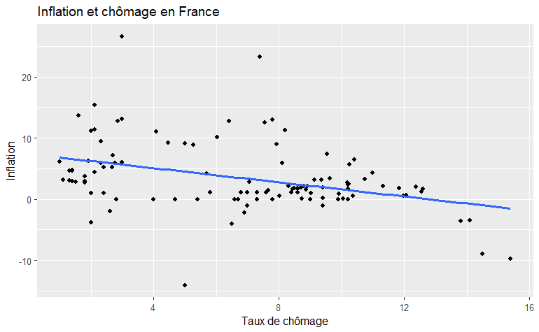

```r
ggplot(donnees2, aes(x = unemp, y = inflation)) +
  geom_point() +
  geom_smooth(method = "lm", se = FALSE) +
  labs(
    x = "Taux de chômage",
    y = "Inflation",
    title = "Inflation et chômage en France"
  )
```

On peut faire l’estimation à la main du coefficient de régression. On sait que le signe de la régression univarié est le même que celui du coefficient de corrélation

```r
cor(donnees2$unemp, donnees2$inflation)
```

```
[1] -0.3790589
```

La corrélation est négative, donc on s’attend a une relation négative entre taux d’inflation et taux de chômage.

Le coefficient de régression à la main:

```r
cov(donnees2$unemp, donnees2$inflation) / var(donnees2$unemp)
```

```
[1] -0.57935
```

Est également négatif. Il y a donc bien une relation négative entre inflation chômage. En revanche, on ne sait pas si cette relation est significativement négative (significativement différente de zéro).

```r
regression_phillips <- feols(inflation ~ unemp, donnees2)
etable(regression_phillips, signif.code = c("***"=0.01, "**"=0.05, "*"=0.10))
```

```
                regression_phillips
Dependent Var.:           inflation

Constant           7.404*** (1.054)
unemp           -0.5793*** (0.1367)
_______________ ___________________
S.E. type                       IID
Observations                    109
R2                          0.14369
Adj. R2                     0.13568
---
Signif. codes: 0 '***' 0.01 '**' 0.05 '*' 0.1 ' ' 1
```

`unemp` est donc négativement et significativement associé à `inflation` au seuil de significativité à 1%, il y a donc bien une relation statistique négative entre inflation et chômage.

Concernant le $R^2$, on voit que le modèle tend à expliquer 14.4% de la variation de l’inflation de la France.